# Public Health and Economic Impacts due to Severe Weather Events

## 1.0 Synopsis

Storms and other severe weather events can cause both public health and economic problems for communities and municipalities. Using data from the U.S. National Oceanic and Atmospheric Administration’s (NOAA) storm database, this analysis demonstrates an answer to these questions:  
a) Across the United States, which types of events are most harmful with respect to population health? - Tornados  
b) Across the United States, which types of events have the greatest economic consequences? - Flood

## 2.0 Data Processing

### 2.1 Global Constants, Libraries, and Functions

```r
    #Constants:
    injury_fatality_ratio <- 20
    topcasualty <- 7 #display the top "x" EVTYPE as measured by casualty
    topdamage <- 6 #display the top "x" EVTYPE as measuered by total damage

    #Libraries:
    require(curl)
    #Functions:
    refactor <- function(x) {
        #http://biocozy.blogspot.com/2011/08/refactor-in-r.html
        x <- factor(x, levels=levels(x)[levels(x) %in% x] )
        return(x)
    }
```

### 2.2 Read Data

```r
    # this data is downloaded from a website (link=file_url, file=data_file_name).
    #This is the original raw data, there is no preprocessing.
    ptm <- proc.time() #start the timer
    setInternet2(use = TRUE)
    data_file_name <- "repdata%2Fdata%2FStormData.csv.bz2"
    file_url <- "https://d396qusza40orc.cloudfront.net"

    #Download the data if it doesn't already exist:
    if(!file.exists(data_file_name)){
        print("Downloading Data")
        download.file(paste(file_url,"/",data_file_name,sep=""),data_file_name, mode = "wb",
                      method = "auto")
    }
```

```
## [1] "Downloading Data"
```

```r
    df<- read.csv(data_file_name)

# There is some documentation of the database available to help undestand the file. Here you will
# find how some of the variables are constructed/defined. Storm Data Documentation =
# https://d396qusza40orc.cloudfront.net/repdata%2Fpeer2_doc%2Fpd01016005curr.pdf
# National Climatic Data Center Storm Events FAQ =
# https://d396qusza40orc.cloudfront.net/repdata%2Fpeer2_doc%2FNCDC%20Storm%20Events-FAQ%20Page.pdf
```

### 2.3 Process Data

In order to quantify the impact to public health I have chosen to combine fatalities and injuries into a single measurement that I called “casualties.” For purposes of this analysis, 20 injuries is assumed to be equal to one fatality.  
In order to quantify the economic impact I am adding the property damage plus the crop damage.

```r
    numuniqueEVTYPE <- length(unique(df$EVTYPE))

####Analysis for impact to public health
    #combine injuries and casualties by ratio to get to a single publich health metric
    df$casualty <- df$INJURIES/injury_fatality_ratio + df$FATALITIES
    #aggregate by EVTYPE
    evagg <- aggregate(list(casualty = df$casualty),by=list(EVTYPE = df$EVTYPE),FUN=sum)
    #order in descending casualty count
    evagg <- evagg[order(-evagg$casualty),]
    evagg$EVTYPE[(topcasualty +1):length(evagg$EVTYPE)] <- "OTHER"
    topcasualtypercent <- round(sum(evagg$casualty[1:topcasualty])/sum(evagg$casualty)*100,0)
    evagg$EVTYPE <- refactor(evagg$EVTYPE)
    evagg2<-evagg[1:(topcasualty+1),]
    evagg2$casualty[topcasualty+1]<- sum(evagg$casualty[evagg$EVTYPE == "OTHER"])
```

```r
####Analysis for economic impact
    #ignore all records that aren't in billions (B,b), Millions (M,m), or Thousands (K,k)
    df$totaldamage <- rep(0,length(df$EVTYPE))
    df$totaldamage <- (df$PROPDMGEXP %in% c("B","b")*1000000000*df$PROPDMG +
                           df$PROPDMGEXP %in% c("M","m")*1000000*df$PROPDMG +
                           df$PROPDMGEXP %in% c("K","k")*1000*df$PROPDMG)
    df$totaldamage <- df$totaldamage + (df$CROPDMGEXP %in% c("B","b")*1000000000*df$CROPDMG +
                           df$CROPDMGEXP %in% c("M","m")*1000000*df$CROPDMG +
                           df$CROPDMGEXP %in% c("K","k")*1000*df$CROPDMG)
    #aggregate by EVTYPE
    damageagg <- aggregate(list(totaldamage = df$totaldamage),by=list(EVTYPE = df$EVTYPE),FUN=sum)
    #order in descending economic impact
    damageagg <- damageagg[order(-damageagg$totaldamage),]
    damageagg$EVTYPE[(topdamage +1):length(damageagg$EVTYPE)] <- "OTHER"
    topdamagepercent <- round(sum(damageagg$totaldamage[1:topdamage])/
                                  sum(damageagg$totaldamage)*100,0)
    damageagg$EVTYPE <- refactor(damageagg$EVTYPE)
    damageagg2<-damageagg[1:(topdamage+1),]
    damageagg2$totaldamage[topdamage+1]<- sum(damageagg$totaldamage[damageagg$EVTYPE == "OTHER"])
```

## 3.0 Results

There are 985 EVTYPEs. The top 7 represent 78% of all casualties.  
The top 6 represent 75% of all economic damages.  
These thresholds were chosen because they represent the fewest amount of EVTYPEs that represent at least 75% of the respective metric.

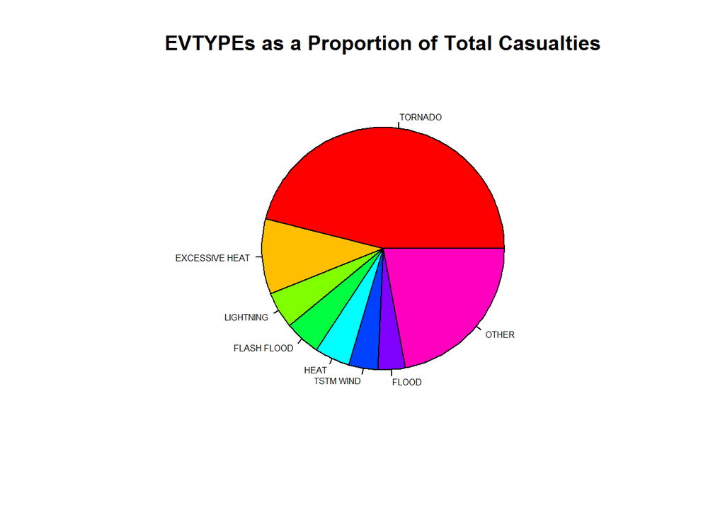

```r
    pie(evagg2$casualty,labels=evagg2$EVTYPE,col=rainbow(length(evagg2$EVTYPE)),cex=1/2,
        main="EVTYPEs as a Proportion of Total Casualties")
```

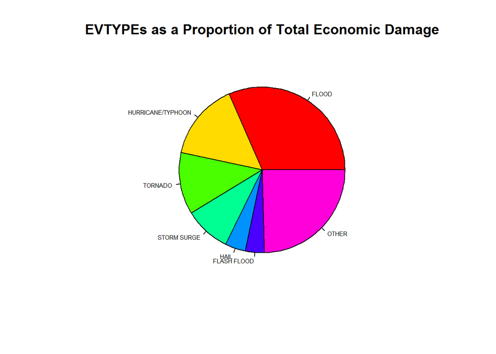

```r
    tophealth <- evagg2[1,1]
    tophealthpercent <- round(evagg2[1,2]/sum(evagg2$casualty)*100,1)

    pie(damageagg2$totaldamage,labels=damageagg2$EVTYPE,col=rainbow(length(damageagg2$EVTYPE)),
        cex=1/2,main="EVTYPEs as a Proportion of Total Economic Damage")
```

```r
    topdamage <- damageagg2[1,1]
    topdamagepercent <- round(damageagg2[1,2]/sum(damageagg2$totaldamage)*100,1)
```

An EVTYPE of TORNADO accounts for 46% of casualties, and therefore represents the event most harmful to public health.  
An EVTYPE of FLOOD accounts for 31.6% of economic damages, and therefore represents the highest economic impact.

## 4.0 Session Information

```r
    date()
```

```
## [1] "Sat Mar 21 22:45:32 2015"
```

```r
    print("Execution Time:")
```

```
## [1] "Execution Time:"
```

```r
    proc.time()-ptm
```

```
##    user  system elapsed
##  159.57    6.73  193.22
```